# Презентация по лабораторной работе №3

Основы информационной безопасности

Бызова М.О.

Российский университет дружбы народов, Москва, Россия

16 марта 2025

## Цель

Получить практические навыки работы в консоли с атрибутами файлов для групп пользователей.

# Выполнение лабораторной работы.

## Создание пользователей

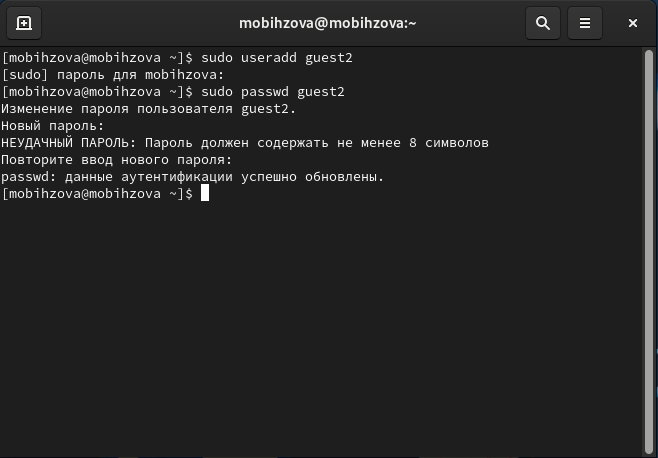

Создание пользователя

## Добавление пользователя в группу

4. Добавляю пользователя guest2 в группу guest

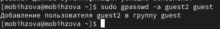

Добавление пользователя в группу

## Вход с двух консолей

5. Зашла на двух разных консолях от имени двух разных пользователей с помощью команды `su <имя пользователя>`

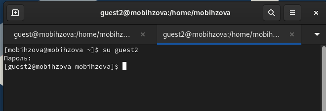

Вход в терминал от имени другого пользователя

## Проверка пути директории

6. Проверяю путь директории, в которой я нахожусь с помощью `pwd`.

Проверка для пользователя guest

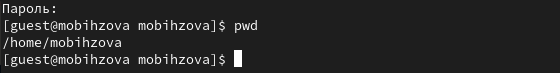

Текущая директория для guest

## Проверка пути директории

Проверка для пользователя guest2

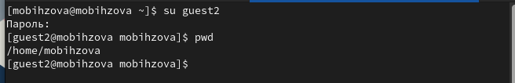

Текущая директория для guest2

## Проверка данных о пользователях

id -Gn - выведет названия групп, которым принадлежит пользователь

id -G - выведет только код групп, которым принадлежит пользователь.

## Проверка данных о группах пользователей

8. Вывела интересующее меня содержимое файла etc/group, видно, что в группе guest два пользователя, а в группе guest2 один

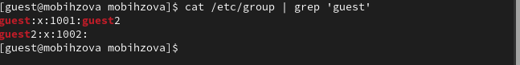

Содержимое файла etc/group

## Регистрация пользователя в группе

9. От имени пользователя guest2 регистрирую его в группе guest с помощью команды `newgrp`

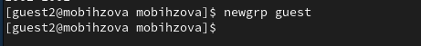

Регистрация пользователя в группе

## Изменение прав директории, в которой будем работать

10. Добавляю права на чтение, запись и исполнение группе пользвателей guest (guest, guest2) на директорию home/guest в которой находятся все файлы для последующей работы

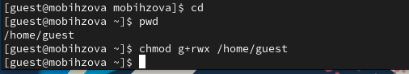

Изменение прав директории

## Изменение прав директории, с которой будем работать

11. От имени пользователя guest снимаю все атрибуты с директории dir1, созданной в предыдущей лабораторной работе. Проверяю, что права действительно сняты.

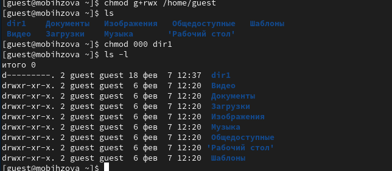

Изменение прав директории

## Заполнение таблицы 3.1

Далее проверяю как пользователь guest2 будет взаимодействовать с файлами в этой директории

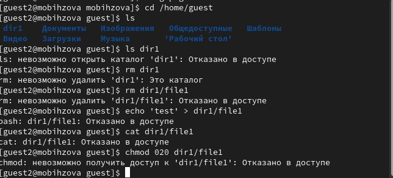

Пример заполнения таблицы 3.1

## Заполнение таблицы 3.2

| Операция | Права на директорию | Права на файл |
| --- | --- | --- |
| Создание файла | `d----wx-— (030)` | `--------— (000)` |
| Удаление файла | `d----wx-— (030)` | `--------— (000)` |
| Чтение файла | `d-----x-— (010)` | `----r---— (040)` |
| Запись в файл | `d-----x-— (010)` | `-----w--— (020)` |
| Переименование файла | `d----wx-— (030)` | `--------— (000)` |
| Создание поддиректории | `d----wx-— (030)` | `--------— (000)` |
| Удаление поддиректории | `d----wx-— (030)` | `--------— (000)` |

## Вывод

Были получены практические навыки работы в консоли с атрибутами файлов для групп пользователей

## Список литературы. Библиография

[0] Методические материалы курса

[1] Права доступа: https://codechick.io/tutorials/unix-linux/unix-linux-permissions

[2] Группы пользователей: https://losst.pro/gruppy-polzovatelej-linux#Что_такое_группы

:::